# 1 Explicação dos dados, a sua origem e relevância

## 10.4 K-Means Clustering

O algoritmo k-means é um método de clustering amplamente utilizado para agrupar dados em k clusters. O k-means tenta encontrar k centróides, que representam os centros dos clusters, minimizando a soma dos quadrados das distâncias entre cada ponto de dados e o centróide do cluster ao qual ele pertence.

## 10.5 Gráfico “elbow”

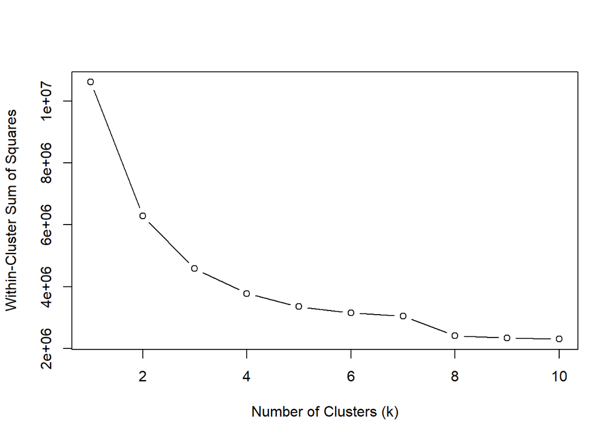

```r
wss <- numeric(10)  #cotovelo

for (k in 1:10) {
  kmeans_result <- kmeans(reduced_data, centers = k)
  wss[k] <- kmeans_result$tot.withinss
}

plot(1:10, wss, type = "b", xlab = "Number of Clusters (k)", ylab = "Within-Cluster Sum of Squares")
```

O gráfico do método do cotovelo (elbow method) é usado para determinar o número ideal de clusters no algoritmo de clustering, como o k-means. Ele ajuda a identificar o ponto de inflexão no gráfico, o “cotovelo”, que indica o número ótimo de clusters para o conjunto de dados. No entanto, este método é heuristico e por isso o resultado do cotovelo pode nao correponder ao numero ideal de clusters.

Pelos resultados observados no gráfico, o ponto de inflexão indica que contém dois clusters para o conjunto de dados.

```r
kmeans_result = kmeans(gbm_assay, centers = 2)
table(kmeans_result$cluster)
```

```
##
##     1     2
##    15 60645
```

```r
kmeans_result1 = kmeans(reduced_data, centers = 2) #com dados do pca
table(kmeans_result1$cluster)
```

```
##
##     1     2
## 60637    23
```

O resultado da análise de agrupamento K-means mostra que os dados foram divididos em dois clusters numerados como 1 e 2.

Devido ao erro “Stack overflow” nos seguintes métodos, vamos utilizar como alternativa os resultados provenientes do PCA, de modo a resolver este problema da capacidade computacional.

# 11 Machine learning

Para a análise através do machine learning, vamos utilizar o dataset ddsSE_IDH. Desta forma, foi feita a previsão para a variável de metadados IDH_status, sendo sido adicionada ao dataset.

```r
df_data = data.frame(as.matrix(assay(ddsSE_IDH)))
dim(df_data)
```

```
## [1] 47966   153
```

### 11.0.1 Criação do dataset

```r
#Alteração feita
df_data_mut = data.frame(group = as.factor(colData(ddsSE_IDH)$paper_IDH.status), t(df_data))
df_data_mut = na.omit(df_data_mut)

# Ordenar o dataframe pelos valores de padj em ordem crescente
res_IDH_sorted <- res_IDH[order(res_IDH$padj), ]

# Selecionar as primeiras 1000 linhas
res_IDH_selected = rownames(res_IDH_sorted)[1:1000]

res_IDH_best = subset(df_data_mut, select = c("group", res_IDH_selected))
```

### 11.0.2 Divisão da amostra

Vamos dividir em duas variáveis, uma para a construção e outra para a testagem do modelo, 70% e 30% respetivamente.

```r
ind = sample(2, nrow(res_IDH_best), replace = T, prob=c(0.7, 0.3))
train = res_IDH_best[ind==1, ]
test = res_IDH_best[ind==2, ]
```

```r
dim(train)
```

```
## [1]  115 1001
```

```r
table(train$group)
```

```
##
## Mutant     WT
##      7    108
```

```r
dim(test)
```

```
## [1]   38 1001
```

```r
table(test$group)
```

```
##
## Mutant     WT
##      4     34
```

É possível ver a distribuição dos subtipos da variável em questão relativamente ao conjunto de dados de treino e de teste.

### 11.0.3 Medidas de erro

```r
pecc = function(obs,pred)

sum(obs==pred)/length(obs)
```

PECC (Percentage Error Correct Classification) é uma métrica de avaliação de desempenho de classificação que mede a percentagem de instâncias classificadas corretamente em relação ao total de instâncias.